# Swire_Capstone_EDA_Group_4

1. Introduction
2. Installing required packages
3. Loading Datasets and Data Description
   - 3.1.Fact Market Demand Data
   - 3.2.Customer Demographics Data
   - 3.3.Zip Code Data
4. Missing Data
   - 4.1.Handling Missing Data
5. Feature Engineering
6. Data Exploration
   - 6.1.Caloric segment Exploration
   - 6.2.Category field Exploration
   - 6.3.Manufacturer Field Exploration
   - 6.4.Brand Field Exploration
   - 6.5.Package field Exploration
   - 6.6.Item field Exploration
   - 6.7.Segment field Exploration
   - 6.8.Zip Code field Exploration
   - 6.9.Markey Key Field Exploration
7. Conclusion
8. Group Member Contribution

# 1. Introduction

Swire Coca-Cola is continually introducing innovative products into the market. Innovation diversifies product offerings, meeting evolving consumer trends. This strategy, marked by unique products and premium pricing, expands market reach and attracts new customers. It responds to technology changes and regulations, ensuring cost efficiency and compliance. Additionally, it rejuvenates sales and marketing. In essence, product innovation is essential for staying relevant, driving revenue, and sustaining long-term growth in a dynamic market.

So, Swire Coca-Cola wants to optimize its production planning and inventory management for these novel beverages. The challenge for Swire is to forecast the demand for these new products accurately to ensure optimal production quantities, prevent out-of-stock and overproduction, minimize costs, and maximize customer satisfaction. The Business problem is to accurately predict the weekly demand of the innovation products. The focus of our project will be on optimal production planning, cost minimization, and market location and date prediction.

The Analytical Problem is to forecast the details expected by the Swire for the 7 innovation products that are planned to be launched in the near future. The basic details of each of the new innovation products are provided so that it can be compared against the historical data and can be used to forecast the sales of the innovation products as close as possible to the real time sales.

The key factors for the Items are the Caloric Segment, Market Category, Manufacturer, Brand, Package Type and Flavor which will be used as the independent variables from the Previous years data to create a Forecast for the new innovation Products. So, the Target variable is the Dollar Sales/unit sales for the innovation products.

The goal of this EDA document is to uncover trends, clusters, and insights to help answer the questions proposed by Swire. Additionally, I want to be open to the possibility of discovering consistancies in the data to anticipate and solve more global questions about Swire’s innovation products. Thus enhancing the oppurtunity to be prepare the data for the modelling part along with gaining the insights on the Data provided.

## Questions

The questions that we are expecting to answer through this EDA document is as follows:

- How Caloric segment effects the sales and how it changes over the seasons
- How the category of drink will impact the sales and which category is the favorite among the customers
- How each of the catagory drinks will change according to time of the year
- What are the top most Manufactures that have high sales for their innovation products
- How the packaging effect the sales for the products
- Will adding the demographic data help in creating a better model ?
- Which segment of people are more likely to buy the Innovation Products

# 2. Installing required packages

```python
import warnings
warnings.filterwarnings("ignore")
```

```python
!pip install google.cloud.bigquery
```

```python
import matplotlib.pyplot as plt
import os
import seaborn as sns
import matplotlib.patches as mp
import matplotlib.image as mpimg
```

```python
from google.cloud import bigquery
from google.oauth2 import service_account
import pandas as pd

from google.colab import auth

# Authenticate user
auth.authenticate_user()
```

```python
# Create a BigQuery client
client = bigquery.Client(project='is-6813-spring-24')
```

# 3. Loading Datasets and Data Description

## 3.1 Fact Market Demand Data

The main data file is the fact_market_demand data since that seems to hold the most value for answering the business problem. There are 10 fields and 24,461,424 rows. The columns are data, unit_sales, caloric_segment, category, manufacturer, brand, package, item, market_key and dollar_sales.

The date range is nearly three full years, spanning December 2020 to October 2023. The caloric segment is a categorical column with values Regular and Diet/light.

```python
# Get Fact_Market_Demand Data from BigQuery

fact_demand_query = """
select * from `swire.fact_market_demand`
"""
# Execute the query
fact_demand_query_job = client.query(fact_demand_query)

# Get the results as a Pandas DataFrame
Fact_Demand_data = fact_demand_query_job.to_dataframe()

# Display Fact_market_demand data
Fact_Demand_data.head()
```

|  | DATE | MARKET_KEY | CALORIC_SEGMENT | CATEGORY | UNIT_SALES | DOLLAR_SALES | MANUFACTURER | BRAND | PACKAGE | ITEM |
| --- | --- | --- | --- | --- | --- | --- | --- | --- | --- | --- |
| 0 | 2022-05-28 | 949 | REGULAR | COFFEE | 4.0 | 9.93 | COCOS | BUBBLE JOY ADVANTAGEOUS COFFEE MOCHA | 12SMALL MLT BUMPY CUP | KOOL! FLAVORED LIQUID COFFEE MOCHA COLA CUP CA... |
| 1 | 2022-07-30 | 133 | REGULAR | COFFEE | 24.0 | 47.93 | COCOS | BUBBLE JOY ADVANTAGEOUS COFFEE MOCHA | 12SMALL MLT BUMPY CUP | KOOL! FLAVORED LIQUID COFFEE MOCHA COLA CUP CA... |
| 2 | 2023-03-18 | 424 | REGULAR | SSD | 1.0 | 11.99 | COCOS | ELF BUBBLES SUMMER SPICED MIXED-FRUIT | 12SMALL 12ONE CUP | ELF BUBBLES GENTLE DRINK SUMMER MELLOW D MIXED... |
| 3 | 2023-01-28 | 161 | REGULAR | SSD | 4.0 | 31.96 | COCOS | ELF BUBBLES SUMMER SPICED MIXED-FRUIT | 12SMALL 12ONE CUP | ELF BUBBLES GENTLE DRINK SUMMER MELLOW D MIXED... |
| 4 | 2022-05-14 | 145 | REGULAR | SSD | 36.0 | 154.85 | COCOS | BUBBLE JOY ADVANTAGEOUS CHERRY VANILLA | 12SMALL 12ONE CUP | KOOL! GENTLE DRINK RED CINNAMON COLA CUP 12 ... |

```python
# Get a summary of the dataset
print(Fact_Demand_data.describe())
```

```
       MARKET_KEY    UNIT_SALES  DOLLAR_SALES
count  24461424.0  2.446142e+07  2.446142e+07
mean   593.140579  1.743710e+02  5.911401e+02
std    605.881271  8.578104e+02  3.040540e+03
min           1.0  4.000000e-02  1.000000e-02
25%         260.0  1.100000e+01  3.659000e+01
50%         547.0  4.000000e+01  1.350500e+02
75%         845.0  1.260000e+02  4.271400e+02
max        6802.0  9.677600e+04  4.925911e+05
```

```python
print(Fact_Demand_data.info())
```

```
<class 'pandas.core.frame.DataFrame'>
RangeIndex: 24461424 entries, 0 to 24461423
Data columns (total 10 columns):
 #   Column           Dtype
---  ------           -----
 0   DATE             dbdate
 1   MARKET_KEY       Int64
 2   CALORIC_SEGMENT  object
 3   CATEGORY         object
 4   UNIT_SALES       float64
 5   DOLLAR_SALES     float64
 6   MANUFACTURER     object
 7   BRAND            object
 8   PACKAGE          object
 9   ITEM             object
dtypes: Int64(1), dbdate(1), float64(2), object(6)
memory usage: 1.8+ GB
None
```

## 3.2 Customer Demographics Data

The customer_demographics data provides information on the demographics with respect to zip codes like Age, Gender with age, Education, Income range, Marraige status, Race and Household information.

All of these demographic information is combined and can be divided by filtering the 'Segment' field for each type like Household income, education, etc.

```python
# Get consumer_demographics Data from BigQuery

demograph_query = """
select * from `swire.consumer_demographics`
"""
# Execute the query
demograph_query_job = client.query(demograph_query)

# Get the results as a Pandas DataFrame
Demographics_data = demograph_query_job.to_dataframe()

# Display Fact_market_demand data
Demographics_data.head()
```

|  | Geography_Name | Zip | City | State | Segment | Criteria | Count | Criteria_Unit |
| --- | --- | --- | --- | --- | --- | --- | --- | --- |
| 0 | 57064 Tea, SD | 57064 | Tea | SD | Household Income | Income Under $10,000 | 36 | HHs |
| 1 | 57064 Tea, SD | 57064 | Tea | SD | Household Income | Income $10,000 - $19,999 | 86 | HHs |
| 2 | 57064 Tea, SD | 57064 | Tea | SD | Household Income | Income $20,000 - $29,999 | 87 | HHs |
| 3 | 57064 Tea, SD | 57064 | Tea | SD | Household Income | Income $30,000 - $39,999 | 137 | HHs |
| 4 | 57064 Tea, SD | 57064 | Tea | SD | Household Income | Income $40,000 - $49,999 | 85 | HHs |

## 3.3 Zip Code Data

This zip to market unit mapping data contains only Zip code to the market key information. This information can be used to connect the Demographics data to the Fact_Market_Demand data and also to know which Market key belongs to which region in country based on the Zip codes.

```python
# Get zip_to_market_unit_mapping Data from BigQuery

zip_market_query = """
select * from `swire.zip_to_market_unit_mapping`
"""
# Execute the query
zip_market_query_job = client.query(zip_market_query)

# Get the results as a Pandas DataFrame
zip_market_data = zip_market_query_job.to_dataframe()

# Display Fact_market_demand data
zip_market_data.head()
```

|  | ZIP_CODE | MARKET_KEY |
| --- | --- | --- |
| 0 | 83462 | 1 |
| 1 | 83463 | 1 |
| 2 | 83466 | 1 |
| 3 | 83467 | 1 |
| 4 | 83525 | 1 |

# 4. Missing Data

```python
# Check for missing value in Demographics data
print(Demographics_data.isnull().sum())
```

```
Geography_Name    0
Zip               0
City              0
State             0
Segment           0
Criteria          0
Count             0
Criteria_Unit     0
dtype: int64
```

```python
# Check for missing values in Zip Market data
print(zip_market_data.isnull().sum())
```

```
ZIP_CODE      0
MARKET_KEY    0
dtype: int64
```

```python
# Check for missing values
print(Fact_Demand_data.isnull().sum())
```

```
DATE                   0
MARKET_KEY             0
CALORIC_SEGMENT    59725
CATEGORY               0
UNIT_SALES             0
DOLLAR_SALES           0
MANUFACTURER           0
BRAND                  0
PACKAGE                0
ITEM                   0
dtype: int64
```

In the Fact Demand data we can see that there are 59725 missing data in the CALORIC_SEGMENT Column. Before replacing that let us look at how the CALORIC_SEGMENT data is disctributed by using the count SQL query from Big Query as the processing time wil be more if done from dataframe object.

```python
# Get Caloric Segment data from Fact_Market_Demand Data from BigQuery

CS_query = """
select CALORIC_SEGMENT,
count(*) as Count_caloric_segment
from `swire.fact_market_demand`
group by CALORIC_SEGMENT;
"""
# Execute the query
CS_job = client.query(CS_query)

# Get the results as a Pandas DataFrame
CS_data = CS_job.to_dataframe()

CS_data.head()
```

|  | CALORIC_SEGMENT | Count_caloric_segment |
| --- | --- | --- |
| 0 | None | 59725 |
| 1 | REGULAR | 12231585 |
| 2 | DIET/LIGHT | 12170114 |

## 4.1 Handling Missing Data

Since both the Regular and Diet/light categories are equal we are unable to categorize the null value to any of the categories without disturbing the other data present. So, We can just replace that Null values with the string of 'Unknown', so that the data is not impacted.

```python
# Handling missing values

Fact_Demand_data['CALORIC_SEGMENT'].fillna('Unknown', inplace=True)
```

```python
# checking for missing data again

print(Fact_Demand_data.isnull().sum())
```

```
DATE               0
MARKET_KEY         0
CALORIC_SEGMENT    0
CATEGORY           0
UNIT_SALES         0
DOLLAR_SALES       0
MANUFACTURER       0
BRAND              0
PACKAGE            0
ITEM               0
dtype: int64
```

# 5. Feature Engineering

Before starting the Data Exploration, we want to include few of the new columns derived from the original data and added into the data.

```python
# Convert DATE column to datetime
Fact_Demand_data['DATE'] = pd.to_datetime(Fact_Demand_data['DATE'])

# Extracting time-related features
Fact_Demand_data['YEAR'] = Fact_Demand_data['DATE'].dt.year
Fact_Demand_data['MONTH'] = Fact_Demand_data['DATE'].dt.month
Fact_Demand_data['WEEK_OF_YEAR'] = Fact_Demand_data['DATE'].dt.isocalendar().week
```

```python
Fact_Demand_data.head()
```

|  | DATE | MARKET_KEY | CALORIC_SEGMENT | CATEGORY | UNIT_SALES | DOLLAR_SALES | MANUFACTURER | BRAND | PACKAGE | ITEM | YEAR | MONTH | WEEK_OF_YEAR |
| --- | --- | --- | --- | --- | --- | --- | --- | --- | --- | --- | --- | --- | --- |
| 0 | 2022-05-28 | 949 | REGULAR | COFFEE | 4.0 | 9.93 | COCOS | BUBBLE JOY ADVANTAGEOUS COFFEE MOCHA | 12SMALL MLT BUMPY CUP | KOOL! FLAVORED LIQUID COFFEE MOCHA COLA CUP CA... | 2022 | 5 | 21 |
| 1 | 2022-07-30 | 133 | REGULAR | COFFEE | 24.0 | 47.93 | COCOS | BUBBLE JOY ADVANTAGEOUS COFFEE MOCHA | 12SMALL MLT BUMPY CUP | KOOL! FLAVORED LIQUID COFFEE MOCHA COLA CUP CA... | 2022 | 7 | 30 |
| 2 | 2023-03-18 | 424 | REGULAR | SSD | 1.0 | 11.99 | COCOS | ELF BUBBLES SUMMER SPICED MIXED-FRUIT | 12SMALL 12ONE CUP | ELF BUBBLES GENTLE DRINK SUMMER MELLOW D MIXED... | 2023 | 3 | 11 |
| 3 | 2023-01-28 | 161 | REGULAR | SSD | 4.0 | 31.96 | COCOS | ELF BUBBLES SUMMER SPICED MIXED-FRUIT | 12SMALL 12ONE CUP | ELF BUBBLES GENTLE DRINK SUMMER MELLOW D MIXED... | 2023 | 1 | 4 |
| 4 | 2022-05-14 | 145 | REGULAR | SSD | 36.0 | 154.85 | COCOS | BUBBLE JOY ADVANTAGEOUS CHERRY VANILLA | 12SMALL 12ONE CUP | KOOL! GENTLE DRINK RED CINNAMON COLA CUP 12 ... | 2022 | 5 | 19 |

The missing data in all the Tables is checked and addressed. The feature engineering is also done. Now moving forward to explore the data.

# 6. Data Exploration

By the Exploration of the Data in Tableau by one of our Group members there are few pictures of the Graphs created in Tableau included along with exploring with the help of Python code.

Let us start exploring with the Unit Sales by taking the sum of its monthly sales and see the trend line for overall data.

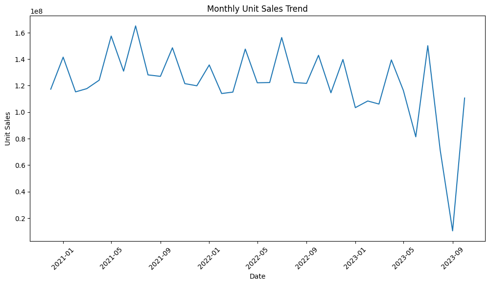

```python
# Aggregate UNIT_SALES by month
monthly_sales = Fact_Demand_data.groupby(Fact_Demand_data['DATE'].dt.to_period('M'))['UNIT_SALES'].sum().reset_index()
monthly_sales['DATE'] = monthly_sales['DATE'].dt.to_timestamp()

plt.figure(figsize=(12, 6))
sns.lineplot(x='DATE', y='UNIT_SALES', data=monthly_sales)
plt.title('Monthly Unit Sales Trend')
plt.xlabel('Date')
plt.ylabel('Unit Sales')
plt.xticks(rotation=45)
plt.show()
```

The Monthly Unit Sales Trend graph offers a clear visualization of sales performance over time, highlighting seasonal variations, trends, and any cyclical patterns present in the data. By observing peaks and troughs, we can pinpoint high-demand periods and potential sales slumps, aiding in inventory and promotional planning. This graph assists in forecasting future sales.

## 6.1. Caloric segment Exploration

To further explore more the next graph is between Sum of the sales for each calorie segment with respect to the each week for whole data.

Unit sales - This variable is used to infer demand for the product, as ordered by Swire merchandisers based on empty store shelves.

Caloric segment - Regular, diet/light, and null/unknown values. Regular is the more popular and by looking at the chart we can also see some seasonality in the peaks in the summer months and high variability at the end of the data range which drags the trendlines down.

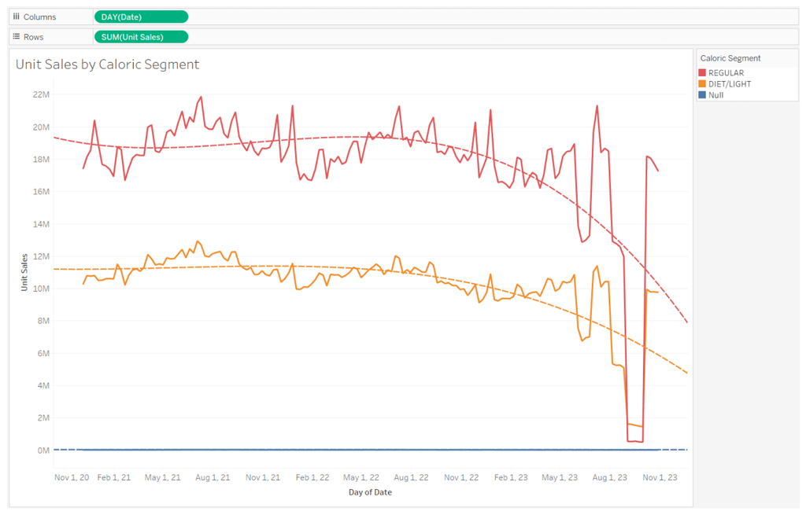

```python
# Specify the path of the image
image_path = '/content/Sum_Sales_to_Calorie_segment.png'

# Display the image using matplotlib
img = mpimg.imread(image_path)
plt.figure(figsize=(15, 12))
plt.imshow(img)
plt.axis('off')  # Hide axis
plt.show()
```

As we can see from above chart the Sum of the unit sales column has high variablility so we are considering the average of the unit sales for each caloric segment with respect to the each week for whole data.

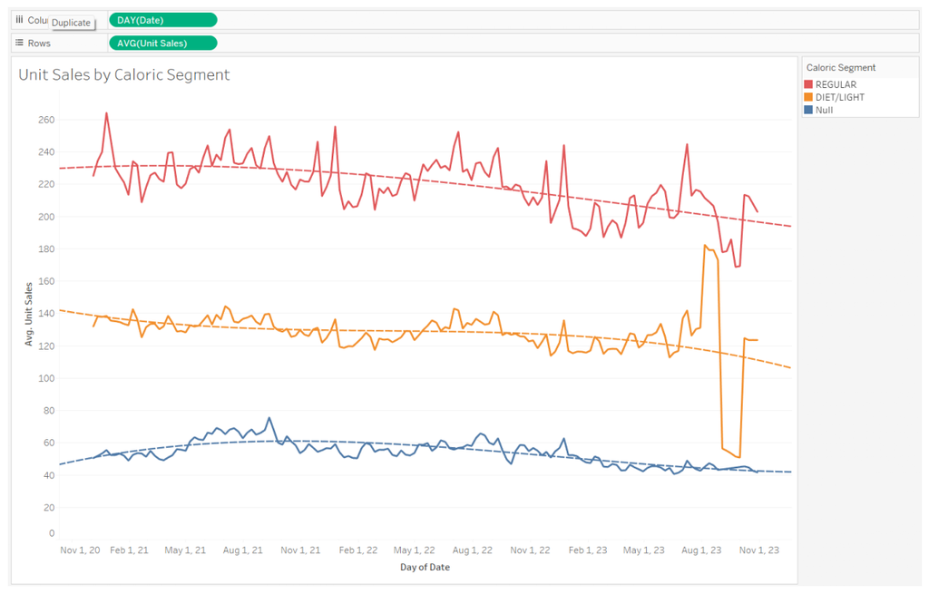

```python
# Specify the path of the image
image_path = '/content/Avg_sales_to_Calorie_Segment.png'

# Display the image using matplotlib
img = mpimg.imread(image_path)
plt.figure(figsize=(15, 12))
plt.imshow(img)
plt.axis('off')  # Hide axis
plt.show()
```

Eventhough from the count of Regular Vs Diet/light we haven't found much difference, but from the average of sales we can clearly say that the Regular drinks will sell much more than Diet/light drinks

## 6.2. Category field Exploration

First lets check how the count of each of the Drinks category is present in data by using the bar chart

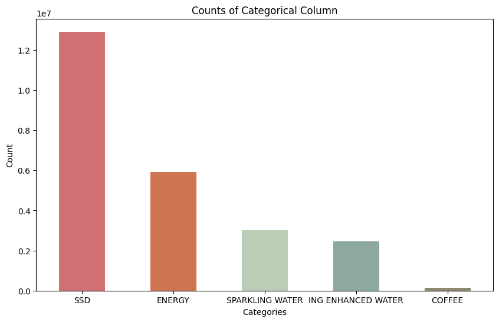

```python
# Count the occurrences of each category
category_counts = Fact_Demand_data['CATEGORY'].value_counts()

# Create a bar chart
plt.figure(figsize=(10, 6))
category_counts.plot(kind='bar', color=['#d17173','#ce7451','#bbcdb5','#8da8a1', '#8e8971'])
plt.title('Counts of Categorical Column')
plt.xlabel('Categories')
plt.ylabel('Count')
plt.xticks(rotation=0)  # Keep x-axis labels horizontal
plt.show()
```

From this we can understand that the most of the products present in the data are SSD category and very few are Coffee category.

Let us explore more and check the same using unit sales and also dates to get more insights on which category of drinks are sold more.

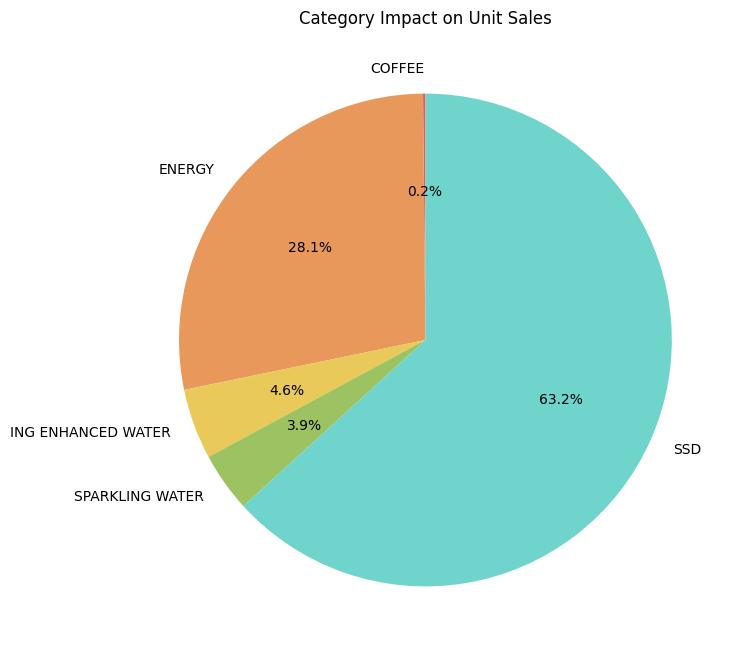

```python
df = pd.DataFrame(Fact_Demand_data)
# Group by category and sum up the unit sales
category_sales = df.groupby('CATEGORY')['UNIT_SALES'].sum()
colors =['#e85a5a','#e8985a','#e8c95a','#9dc262', '#6ed4cc', '#d17173']
# Plotting a pie chart
plt.figure(figsize=(8, 8))
plt.pie(category_sales, labels=category_sales.index, autopct='%1.1f%%', startangle=90, colors=colors)
plt.title('Category Impact on Unit Sales')
plt.show()
```

This clearly shows how various category types affect the sales ratio. However, SSD have the biggest impact on sales, comprising about 63.2% of total sales, making them the most influential category for customers.

In the upcoming innovation product ideas that the Swire-CC has provided, we can see that there are 2 products which comes under SSD category and 2 products which comes under Energy category, So the sales of these will be high with respect to the other 3 innovation products from the above pie chart.

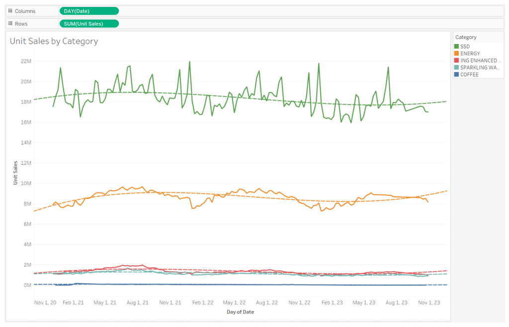

```python
# Specify the path of the image
image_path = '/content/unit_sales_category.png'

# Display the image using matplotlib
img = mpimg.imread(image_path)
plt.figure(figsize=(15, 12))
plt.imshow(img)
plt.axis('off')  # Hide axis
plt.show()
```

A breakout of unit sales by category displays which have higher unit sales and how popular each category is. The summer drink seasonality is apparent in SSD, energy, and even in the water categories. Large spikes are also apparent with the SSD’s, which unsurprisingly, seem to coincide with major U.S. holidays.

By segmenting the unit sales by year one can clearly see the similar overlap of holiday spikes in 2021, 2022, and most of 2023.

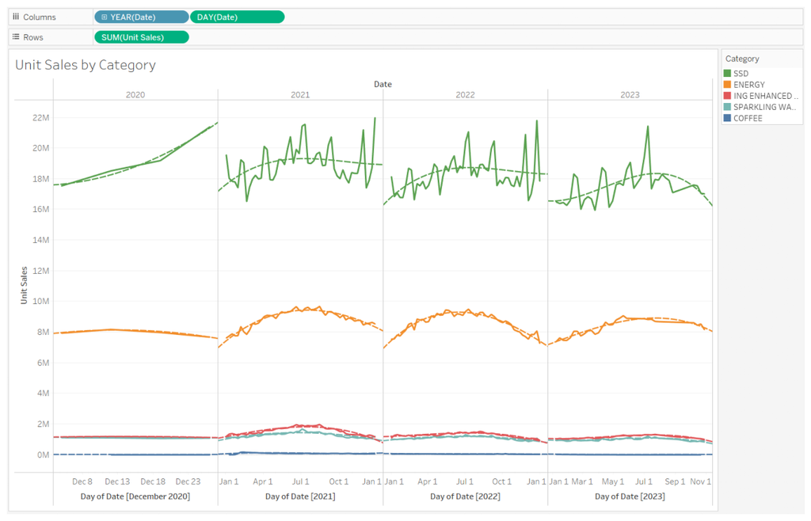

```python
# Specify the path of the image
image_path = '/content/sales_category_year.png'

# Display the image using matplotlib
img = mpimg.imread(image_path)
plt.figure(figsize=(15, 12))
plt.imshow(img)
plt.axis('off')  # Hide axis
plt.show()
```

Combining caloric segment and category provides the following graph. Regular is the thicker line and diet/light is the thin line within the same color.

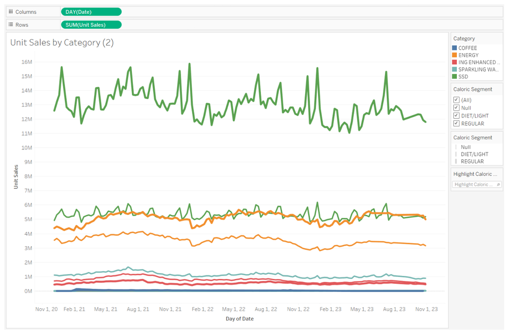

```python
# Specify the path of the image
image_path = '/content/sales_category_calories_segment.png'

# Display the image using matplotlib
img = mpimg.imread(image_path)
plt.figure(figsize=(15, 12))
plt.imshow(img)
plt.axis('off')  # Hide axis
plt.show()
```

As evident, regular outperformes diet in most prominent categories like SSD and ENERGY. The other category sales are less compared to the SSD and ENERGY.

In the upcoming innovation product ideas that the Swire-CC has provided, we can see that there are 2 products which comes under SSD category and 2 products which comes under Energy category, So the sales of these will be high with respect to the other 3 innovation products which is observed from the above 3 charts.

## 6.3. Manufacturer Field Exploration

First let us see the count of the number of rows present for each of the manufacturer.

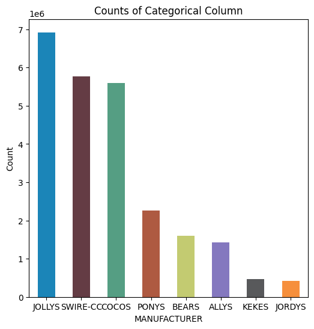

```python
# Count the occurrences of each category
category_counts = Fact_Demand_data['MANUFACTURER'].value_counts()

# Create a bar chart
plt.figure(figsize=(6, 6))
category_counts.plot(kind='bar',
         color=['#1b85b8','#643c44','#559e83','#ae5a41',
                '#c3cb71', '#8478bf','#58595b', '#f68f3c'])
plt.title('Counts of Categorical Column')
plt.xlabel('MANUFACTURER')
plt.ylabel('Count')
plt.xticks(rotation=0)  # Keep x-axis labels horizontal
plt.show()
```

To keep things consistent, let’s look at manufacturers by unit sales count.

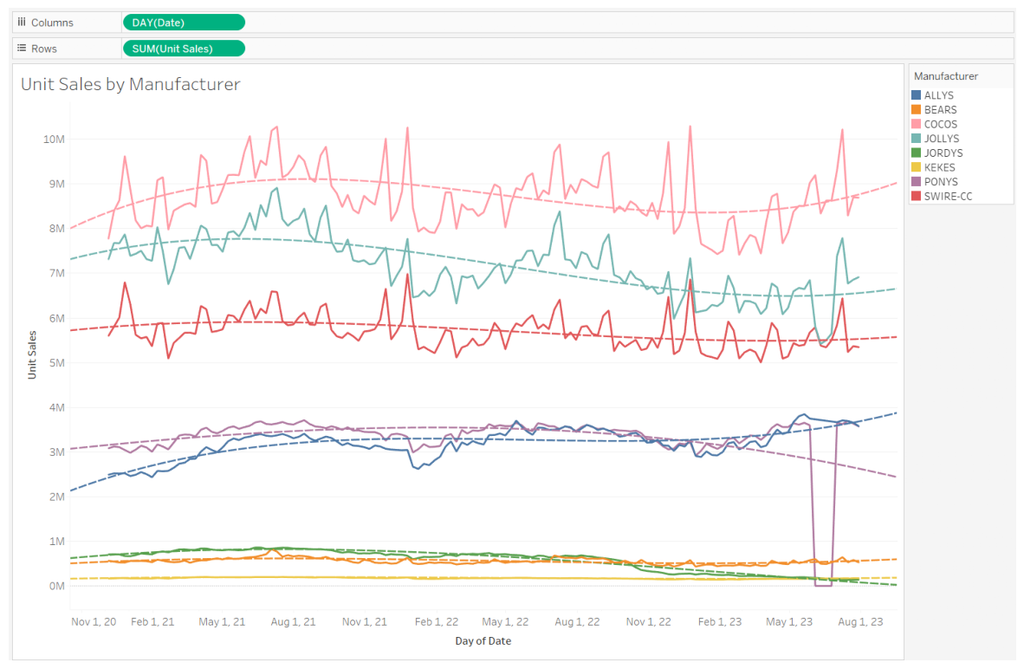

```python
# Specify the path of the image
image_path = '/content/unit_sales_manufacturer.png'

# Display the image using matplotlib
img = mpimg.imread(image_path)
plt.figure(figsize=(15, 12))
plt.imshow(img)
plt.axis('off')  # Hide axis
plt.show()
```

From the above chart, we can see that the Cocos, Jollys, and Swire-CC are the top three by unit sales, with the rest of the manufacturers in the bottom half of sales.

## 6.4. Brand Field Exploration

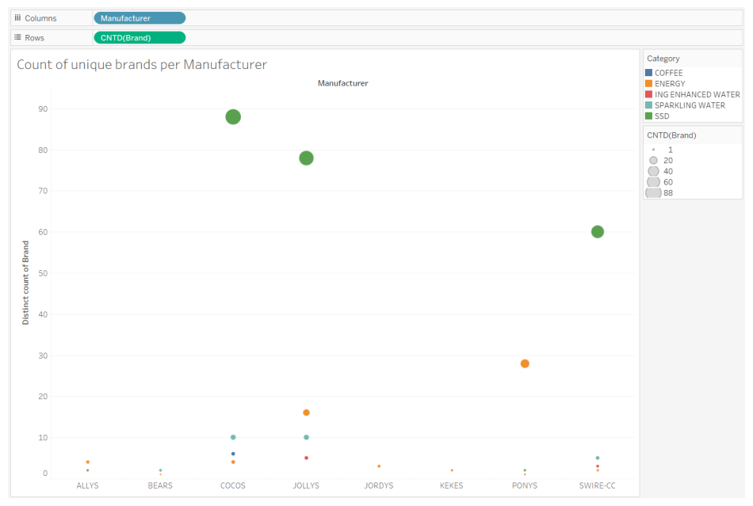

```python
# Specify the path of the image
image_path = '/content/brand_category_manufacturer.png'

# Display the image using matplotlib
img = mpimg.imread(image_path)
plt.figure(figsize=(12, 10))
plt.imshow(img)
plt.axis('off')  # Hide axis
plt.show()
```

Brand of the items, many brands are within one manufacturer. There are 319 brands between the eight manufacturers with most from Cocos, Jollys, and Swire. By breaking out brands by manufacturers you can see that some brands are only producing drinks in certain categories, and SSD’s seems to have the highest count of brands.

## 6.5. Package Field Exploration

There are 103 different package options in the dataset that appear to describe various elements of the fluid amount, quantity, and container type. A package histogram sorted by unit sales revels the most popular packages with the remaining options training with low numbers. Coloring by category provides further insight to overlapping and distinct packaging.

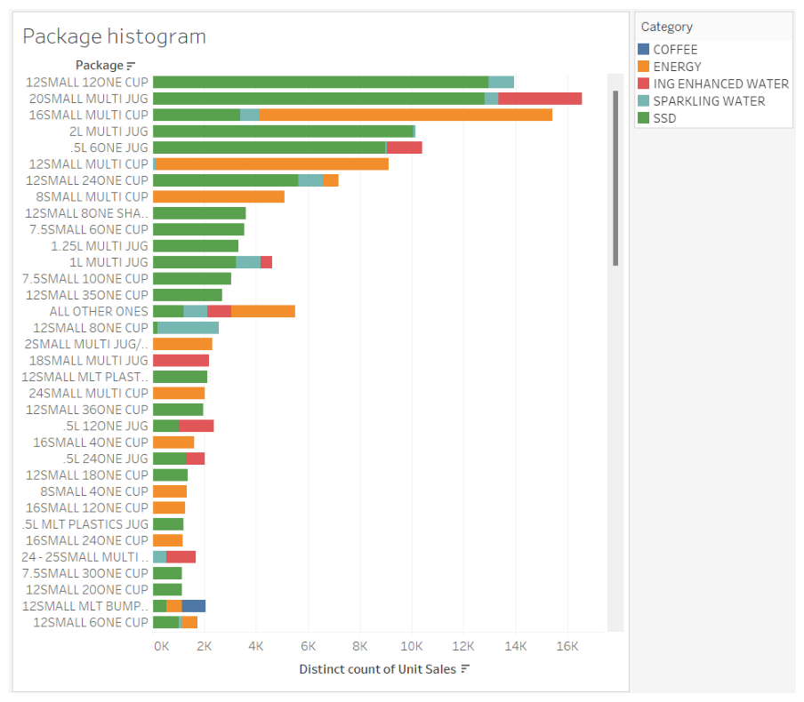

```python
# Specify the path of the image
image_path = '/content/package_category.png'

# Display the image using matplotlib
img = mpimg.imread(image_path)
plt.figure(figsize=(15, 10))
plt.imshow(img)
plt.axis('off')  # Hide axis
plt.show()
```

Clustering the packages shows how Tableau grouped the top three, next three, and the rest into clusters.

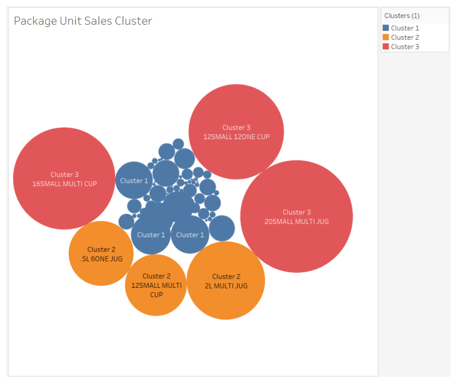

```python
# Specify the path of the image
image_path = '/content/package_cluster.png'

# Display the image using matplotlib
img = mpimg.imread(image_path)
plt.figure(figsize=(10, 8))
plt.imshow(img)
plt.axis('off')  # Hide axis
plt.show()
```

## 6.6. Item Field Exploration

The content in the item column is a description of the item sold. This column is the longest has the longest text characters and the most unique values with 3,692. The description includes anonymized flavors and a repeat of the packaging. Since these are not the actual flavors, more analysis may be required to evaluate the value of this variable, aside from the coded flavor questions by Swire. Exploring the data we see that the SSD and Energy categories dominate the most unit sales.

The below graph represents the Dollar sales of items by date for top 5 ITEMS which high unit sales for overall period of time

```python
# Get Unit Sales data for top 5 items from Fact_Market_Demand Data from BigQuery

item_5_query = """
select distinct ITEM,
round(Sum(unit_sales),2) as unit_sales_total
from `swire.fact_market_demand`
group by ITEM
order by unit_sales_total desc
limit 5;
"""
# Execute the query
item_5_job = client.query(item_5_query)

# Get the results as a Pandas DataFrame
item_5_data = item_5_job.to_dataframe()

item_5_data.head()
```

|  | ITEM | unit_sales_total |
| --- | --- | --- |
| 0 | MYTHICAL BEVERAGE ENERGY DRINK UNFLAVORED CUP ... | 1.103561e+08 |
| 1 | KOOL! GENTLE DRINK COLA JUG 20 LIQUID SMALL | 1.038452e+08 |
| 2 | KOOL! GENTLE DRINK COLA CUP 12 LIQUID SMALL X12 | 9.860047e+07 |
| 3 | REAL-TIME ENERGY DRINK UNFLAVORED CUP 12 LIQUI... | 9.412952e+07 |
| 4 | PEPPY GENTLE DRINK RED PEPPER COLA JUG 20 LIQ... | 7.952519e+07 |

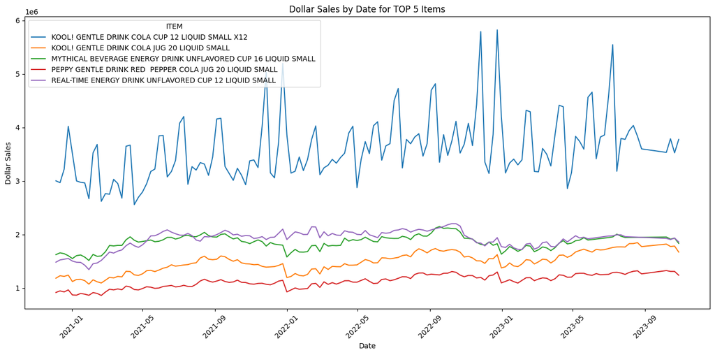

```python
# Aggregate DOLLAR_SALES by DATE for each ITEM
item_sales_by_date = Fact_Demand_data.groupby(['DATE', 'ITEM'])['DOLLAR_SALES'].sum().reset_index()

filtered_data = item_sales_by_date[item_sales_by_date['ITEM'].isin(item_5_data.ITEM)]

plt.figure(figsize=(14, 7))
sns.lineplot(data=filtered_data, x='DATE', y='DOLLAR_SALES', hue='ITEM')
plt.title('Dollar Sales by Date for TOP 5 Items')
plt.xlabel('Date')
plt.ylabel('Dollar Sales')
plt.xticks(rotation=45)
plt.tight_layout()
plt.show()
```

So, we can consider the characteristics of this item like the category, type, packaging which can be further for the forecast of similar future innovation products and can also be considered for targeting the market where this item is sold most.

## 6.7. Segment field Exploration

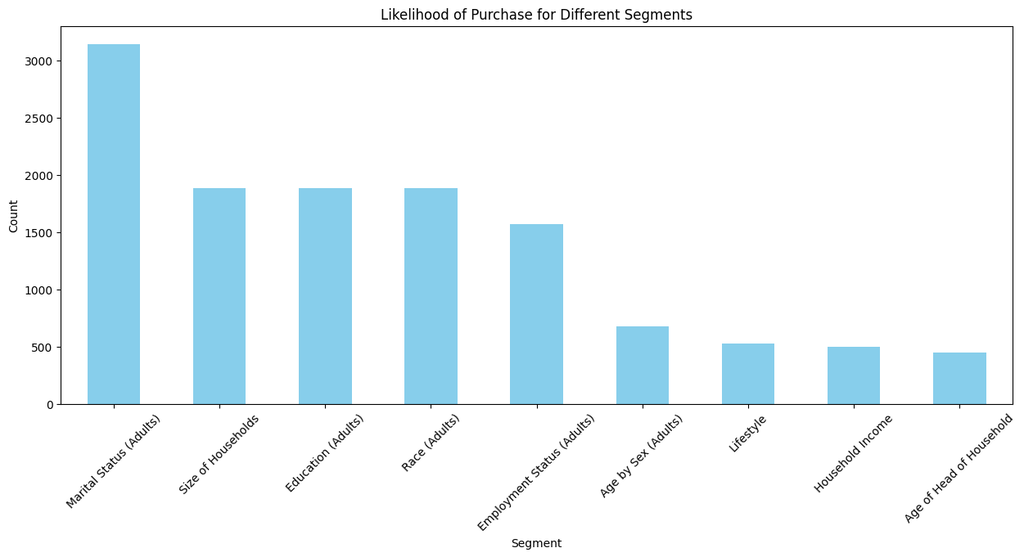

```python
df = pd.DataFrame(Demographics_data)

# Query to calculate the count of customers for each segment
purchase_likelihood = df.groupby('Segment')['Count'].mean().sort_values(ascending=False)

# Plotting the results
plt.figure(figsize=(15, 6))
purchase_likelihood.plot(kind='bar', color='skyblue')
plt.title('Likelihood of Purchase for Different Segments')
plt.xlabel('Segment')
plt.ylabel('Count')
plt.xticks(rotation=45)
plt.show()
```

This graph helps to identify segments with the highest number of customers in each segment. By visually comparing the heights of the bars, it becomes evident that Marital status segment holds the highest customers according to the segments.

```
Top 10 Records:
                   Segment                    Criteria  Count
273300       Race (Adults)              Race: Hispanic  68543
451212       Race (Adults)              Race: Hispanic  67036
404340       Race (Adults)              Race: Hispanic  66135
430996       Race (Adults)              Race: Hispanic  64589
274868       Race (Adults)              Race: Hispanic  58870
272852       Race (Adults)              Race: Hispanic  56260
213268       Race (Adults)              Race: Hispanic  53833
479828       Race (Adults)              Race: Hispanic  52645
368892       Race (Adults)              Race: Hispanic  50520
435140       Race (Adults)              Race: Hispanic  49568
273335  Size of Households        5+ Person Households  48668
428980       Race (Adults)              Race: Hispanic  48446
216292       Race (Adults)              Race: Hispanic  47628
177202       Race (Adults)  Race: White (Non-Hispanic)  47091
437380       Race (Adults)              Race: Hispanic  47088
431612       Race (Adults)              Race: Hispanic  46827
191874       Race (Adults)  Race: White (Non-Hispanic)  46510
314402       Race (Adults)  Race: White (Non-Hispanic)  46113
214668       Race (Adults)              Race: Hispanic  45595
431031  Size of Households        5+ Person Households  45327
```

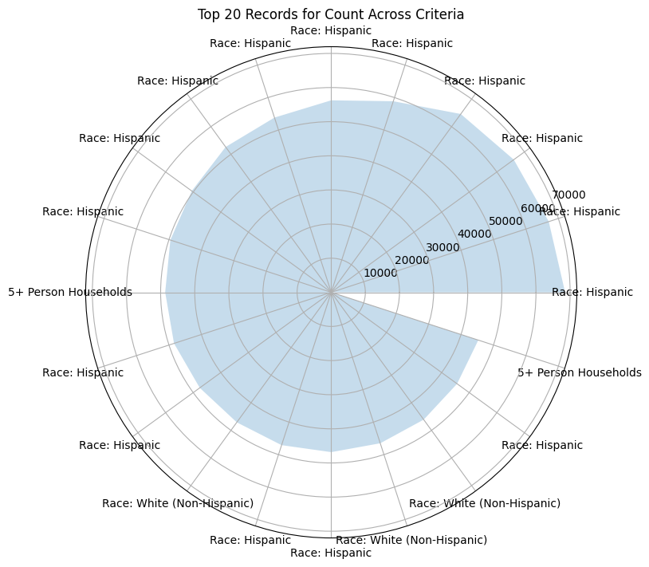

```python
from math import pi

# Sort the DataFrame by count in descending order
sorted_data = Demographics_data.sort_values(by='Count', ascending=False)

top_10_data = sorted_data.head(20)

# Display the information
print("Top 10 Records:")
print(top_10_data[['Segment', 'Criteria', 'Count']])

#  Radar chart for income types and ranges
categories = list(top_10_data['Criteria'])
values = list(top_10_data['Count'])

fig, ax = plt.subplots(figsize=(8, 8), subplot_kw=dict(polar=True))
ax.fill_between([i / len(categories) * 2 * pi for i in range(len(categories))], values, alpha=0.25)
ax.set_xticks([i / len(categories) * 2 * pi for i in range(len(categories))])
ax.set_xticklabels(categories)
ax.set_title('Top 20 Records for Count Across Criteria')
plt.show()
```

This radar chart shows the top 20 records for 'Count' across different criteria. The criteria with the highest count is "Hispánic" with around 68543, followed by "5+ Person Households" with around 48668 and "White (Non-Hispanic)" with around 47091. The data is dominated by the *Hispanic population* and *large households.*

This has to be further explored as there are several sub-categories for the Segment. And also this information hasto be explored by connecting with fact_demand table using the zip-market connecting table.

This has to be further explored as there are several sub-categories for the Segment. And also this information hasto be explored by connecting with fact_demand table using the zip-market connecting table.

## 6.8. Zip Code Field Exploration

[figure not shown]

```python
df = pd.DataFrame(Demographics_data)

# Sort the DataFrame by count of people in descending order and get top 10
top_10_zipcodes = df.sort_values(by='Count', ascending=False).head(10)

# Plotting using Seaborn
plt.figure(figsize=(15, 6))

# Bar plot
sns.barplot(x='Zip', y='Count', data=top_10_zipcodes, palette='viridis', order=top_10_zipcodes['Zip'])
plt.title('Top 10 Zipcodes with population')
plt.xlabel('Zipcode')
plt.ylabel('Count of people')
plt.show()
```

According to the data, California can be a major market for the product being sold as there are more people present. This has to be cross verified by connecting the demographics data to the fact_demand data, which wil be done in the next phase of Project.

## 6.9. Markey Key Field Exploration

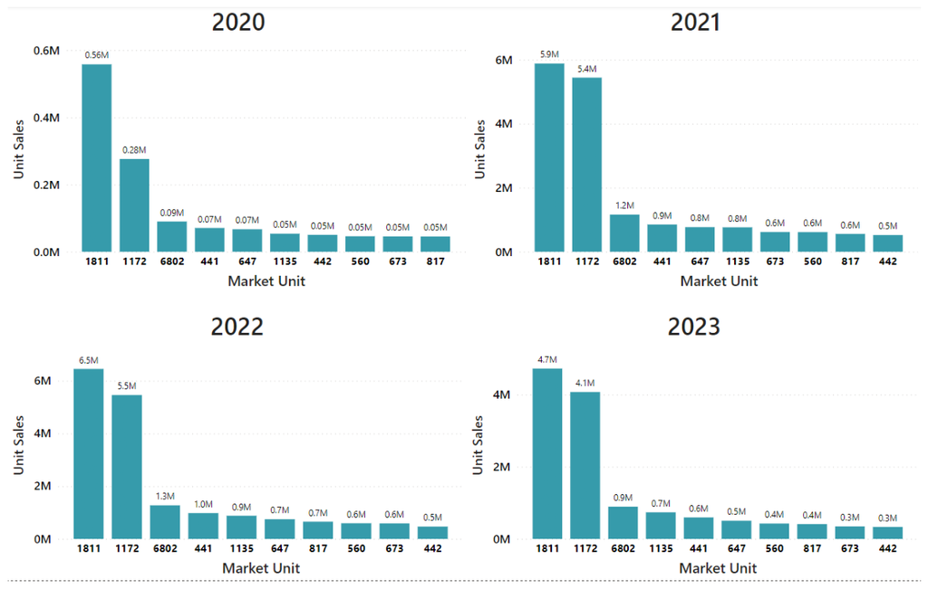

```python
#Specify the path of the image
image_path = '/content/image.png'

# Display the image using matplotlib
img = mpimg.imread(image_path)
plt.figure(figsize=(15, 10))
plt.imshow(img)
plt.axis('off')  # Hide axis
plt.show()
```

This clearly shows the top ten market units with the highest sales count throughout all years. The market unit with the highest number of sales is "1811". This analysis is useful to have more context about the product being sold, the time period, and the market conditions in order to make more accurate interpretations.

# 7. Conclusion

This data set benefits greatly from disaggregating the values into its constituent parts to identify different trends and categories influencing unit sales. This EDA uncovered valuable popular caloric segments, beverage categories, and manufacturers. Seasonal trends and holiday sale spikes were also identified and will be useful in timing new innovation products. Brands, packages, and items are extensive and will help provide additional details to add to the other variables.

All the insights that are found can be used to mode forward in the modelling procss like finding that the Regular Caloric segment will lead to the higher number of sales rather than Diet/Light. This information can be trasformed and used when the forecasting of the new Innovative Products is done.

Also, from the exploration in the demographics data we have found that the Carifornia is a potential market as it is the most populated region, this has to be further explored by connecting the demographic dataset with the fact_demand dataset which will be concentrated on during the Modelling phase of the project.

Overall, for the forecast of the new Innovation products provided, we have considered that the Regular drinks are sold more when compared to the Diet/light drinks and also, the Energy and SSD type drinks are more sold than the other categories. These points are derived from EDA and will be used as the key points when the forecasting model is being created.

# 8. Group Member Contribution